# hw_3

Holden Mitchell

9/15/2017

## Homework 3

- Use your own data and the R function pairs (~VAR1+VAR2+VAR3+VAR4, data=DATA, main=“Basic Scatter Plot Matrix”) to generate a graph
- 3-19, 3-42 (a-f), 3-46, 3-60 (may use the WHILE loop in R);
- Probability plots using R for: Binomial distribution, Poisson, Uniform, Exponential, Normal

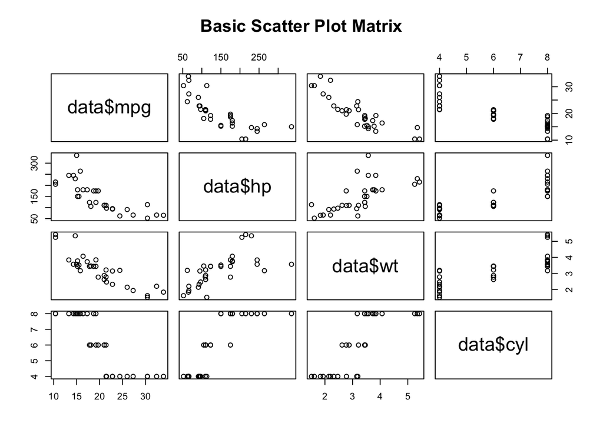

```r
data=mtcars
# Make the plot
pairs(~data$mpg+data$hp+data$wt+data$cyl, data=NULL, main="Basic Scatter Plot Matrix")
```

#### 3-19

```r
x <- c(1700,1500,1200,1000,800,600,400)
p <- c(.2,.2,.3,.1,.1,.05,.05)
data <- data.frame(millions=x, probability=p, mean=(x*p), variance=(x^2*p))
mean <- sum(data$mean)
mean
```

```
## [1] 1230
```

```r
var_sum <- sum(data$variance)
variance <- var_sum - mean^2
variance
```

```
## [1] 137100
```

```r
std_dev <- sqrt(variance)
std_dev
```

```
## [1] 370.2702
```

- Mean: 1230
- Variance: 137100
- Standard Deviation: 370.27

#### 3-42 (a-f)

probability = 0.2107

##### a

15 demonstrations 4 orders

```r
dbinom(4, 15, .2107)
```

```
## [1] 0.1992755
```

##### b

16 demonstrations 4 orders

```r
pbinom(4, 16, .2107)
```

```
## [1] 0.7651031
```

##### c

17 demonstrations 4 orders

```r
pbinom(4, 17, .2107)
```

```
## [1] 0.7209156
```

##### d

18 demonstrations 4 to 8 orders

```r
a = dbinom(4:8, 18, .2107)
a
```

```
## [1] 0.21966912 0.16419105 0.09496510 0.04345799 0.01595125
```

##### e

90% confident of 4 orders+ How many demonstrations?

```r
qbinom(.9, 30, .2107, lower.tail = FALSE)
```

```
## [1] 4
```

- Demonstrations = 30

##### f

22 demonstrations 90% confident of 4 orders What probability needed? (Four decimals)

```r
pbinom(4, 22, .33104)
```

```
## [1] 0.1000006
```

- Probability = .33104

#### 3-46

0.71 crashes per semester

##### a

Probability of 2 crashes

```r
ppois(2, lambda=.71, lower.tail = FALSE)
```

```
## [1] 0.0353695
```

##### b

Probability of no crashes

```r
ppois(0, lambda=.71)
```

```
## [1] 0.4916442
```

##### c

Probability to 90%. Largest $\mu$ to achieve goal?

```r
ppois(0, lambda=.90)
```

```
## [1] 0.4065697
```

#### 3-60

Bus comes every 15 mins Student allows 10 mins waiting time for shuttle to make it to class

##### a

```r
possible_wait <- c(1,2,3,4,5,6,7,8,9,10,11,12,13,14,15)
variance <- var(possible_wait)
variance
```

```
## [1] 20
```

Expected wait time: 7.5 mins

Variance: 20

##### b

Probability 4-6 minutes: .1333

```r
x<-punif (6, min = 0 , max = 15)
y<-punif (4, min = 0 , max = 15)
x-y
```

```
## [1] 0.1333333
```

##### c

Probability student on time: .6667

```r
punif (10, min = 0 , max = 15)
```

```
## [1] 0.6666667
```

##### d

95% confident of being on time. How much time should he wait?

```r
qunif(.95, min=0, max=15, lower.tail=TRUE)
```

```
## [1] 14.25
```

Time: 14.25 mins

#### Probability plots

##### Binomial Distribution

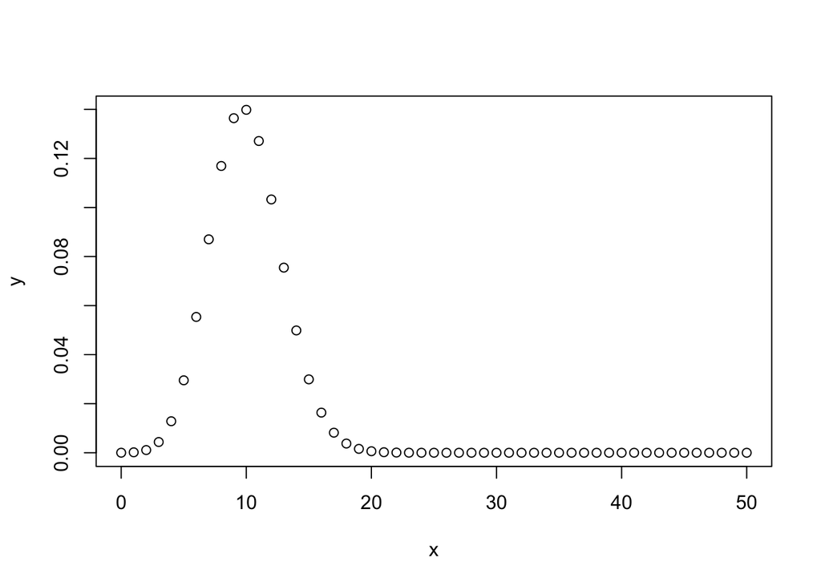

```r
x <- seq(0,50,by=1)
y <- dbinom(x,50,0.2)
plot(x,y)
```

##### Poisson

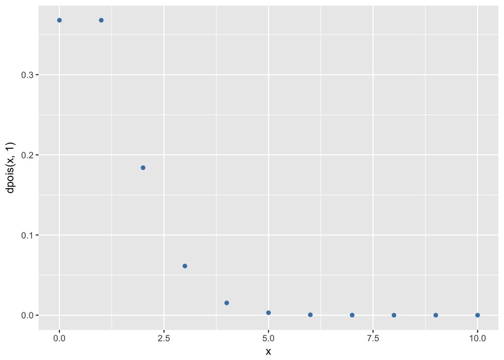

```r
ggplot(data.frame(x=c(0:10)), aes(x)) +
    geom_point(aes(y=dpois(x, 1)), colour="steelblue")
```

##### Uniform

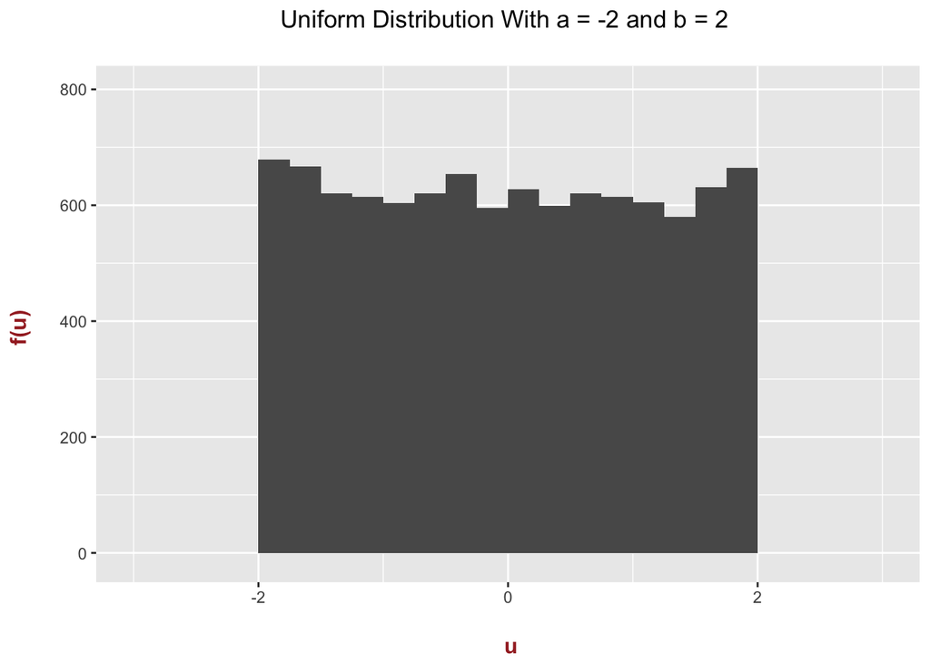

```r
unifs <- runif(n = 10000, min = -2, max = 2)

ggplot(data = NULL, aes(x = unifs)) +
  geom_histogram(binwidth = 0.25, boundary = 2) +
  xlim(c(-3, 3)) +
  ylim(c(-10, 800)) +
  labs(x = "\n u", y = "f(u) \n", title = "Uniform Distribution With a = -2 and b = 2 \n") +
  theme(plot.title = element_text(hjust = 0.5),
        axis.title.x = element_text(face="bold", colour="brown", size = 12),
        axis.title.y = element_text(face="bold", colour="brown", size = 12))
```

##### Exponential

```r
  lower <- floor(qexp(0.001, rate=0.2))
  upper <- ceiling(qexp(0.999, rate=0.2))
  t <- seq(lower,upper,0.1)
  q <- seq(0.001,0.999,0.001)
  dexp02 <- data.frame(T=t,
                        Density=dexp(t, rate=0.2),
                        Distribution=pexp(t, rate=0.2))
  qexp02 <- data.frame(Q=q, Quantile=qexp(q, rate=0.2))
  head(dexp02)
```

```
##     T   Density Distribution
## 1 0.0 0.2000000   0.00000000
## 2 0.1 0.1960397   0.01980133
## 3 0.2 0.1921579   0.03921056
## 4 0.3 0.1883529   0.05823547
## 5 0.4 0.1846233   0.07688365
## 6 0.5 0.1809675   0.09516258
```

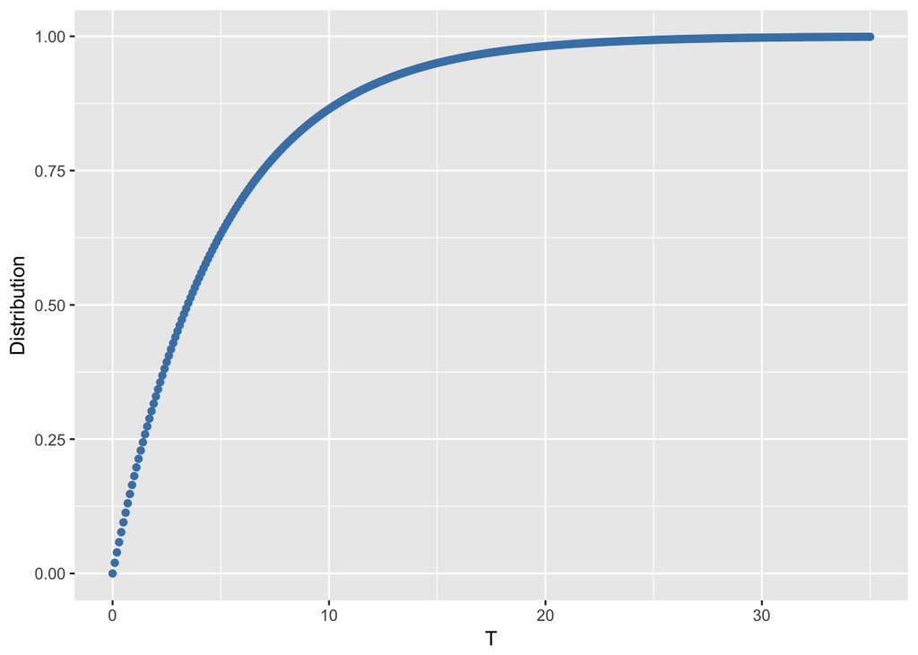

```r
ggplot(dexp02, aes(x=T)) +
    geom_point(aes(y=Distribution), colour="steelblue")
```

##### Normal

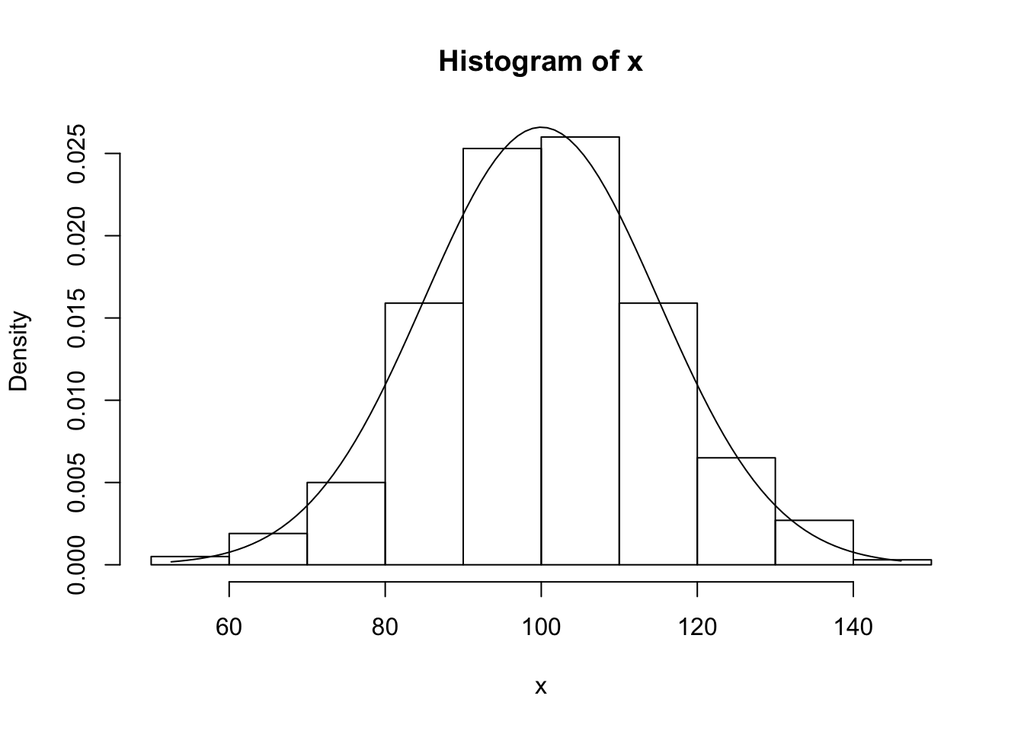

```r
########normal distribution
x <- rnorm(1000, mean=100, sd=15)
hist(x, probability=TRUE)
xx <- seq(min(x), max(x), length=100)
lines(xx, dnorm(xx, mean=100, sd=15))
```